# Биомаркеры рака груди

Фокина Дарья

Есть 3 группы людей: здоровые, люди с заболеванием на ранней стадии, люди с сильно выраженными симптомами. Необходимо найти гены со статистически и практически значимыми различиями в уровнях экспрессии для 1й и 2й групп, 1й и 3й групп.

```r
cancer.data <- read.csv("gene_high_throughput_sequencing.csv")
print(ncol(cancer.data))
```

```
[1] 15750
```

Как видно, дано огромное количество генов.

1. Разделим данные на 3 группы по типу пациентов:

```r
normal <- subset.data.frame(cancer.data, Diagnosis == "normal")
early.neoplasia <- subset.data.frame(cancer.data, Diagnosis == "early neoplasia")
cancer <- subset.data.frame(cancer.data, Diagnosis == "cancer")
```

2. Сравним уровни экспрессии генов в группе здоровых людей и группе людей с ранней стадией рака. Найдем практически значимые отклонения

```r
fold.change <- function(control,treatment){
    return(abs(ifelse(mean(control) > mean(treatment),mean(control) / mean(treatment),mean(treatment) / mean(control)))>1.5)
}
```

```r
is.practical1 <- mapply(fold.change,normal[3:ncol(normal)],early.neoplasia[3:ncol(early.neoplasia)])
data1 <- subset.data.frame(cancer.data,subset = ((Diagnosis == "normal") | (Diagnosis == "early neoplasia")), select = append("Diagnosis", names(is.practical1)[is.practical1==TRUE]))
```

3. Проведем дисперсионный анализ для каждого гена:

```r
p.values.vec1 = list()
for (i in 2:ncol(data1)){
  aov.sum1 <- summary(aov(data1[,i] ~ Diagnosis,data = data1))
  p.values.vec1 <- c(p.values.vec1,aov.sum1[[1]][["Pr(>F)"]][1])
}
```

4. Сделаем поправку на множественность:

```r
corrected.pvalues1 <- p.adjust(p.values.vec1,method = "holm")
```

5. Выберем только те гены, где p.value < 0.05

```r
data.names1 <- colnames(data1)
list_of_influencing_genes1 <- c()
for (x in 1:length(corrected.pvalues1)){
  if(corrected.pvalues1[x] < 0.05){
    list_of_influencing_genes1 <- c(list_of_influencing_genes1,data.names1[x+1])
  }
}
print(list_of_influencing_genes1)
```

```
 [1] "LOC100130417" "KLHDC7A"      "TTC39A"       "PIGR"         "CAPN8"        "MYOZ1"        "SYT9"         "ALDH3B2"      "CCDC42B"
[10] "HS6ST3"       "SIX1"         "TMEM63C"      "LOC100507043" "FSIP1"        "IGDCC3"       "WNK4"         "CACNG4"       "CACNG1"
[19] "PCSK4"        "CACNG8"       "C19orf51"     "TRIM54"       "ABCA12"       "C2orf54"      "ZBP1"         "EEF1A2"       "SLC34A2"
[28] "INPP4B"       "RASGEF1C"     "MYB"          "FZD9"         "LOC100131176" "COL4A5"
```

6. Так как количество генов достаточно большое, приведем визуализацию только для двух из них: KLHDC7A (есть в списке значимых генов) и NOC2L (нет в этом списке)

```r
par(mfrow = c(2,2))
boxplot(normal$KLHDC7A)
boxplot(early.neoplasia$KLHDC7A)
```

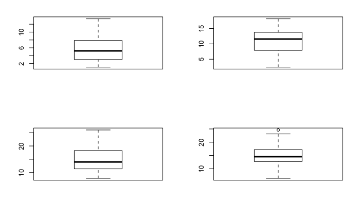

```r
boxplot(normal$NOC2L)
boxplot(early.neoplasia$NOC2L)
```

Как видно, в первом случае действительно есть значимое различие у уровнях экспрессии, а во втором случае - нет.

7. А теперь рассмотрим сравнение уровней экспрессии генов для группы из здоровых людей и группы больных раком. Для начала выделим гены с практически значимыми отклонениями:

```r
is.practical2 <- mapply(fold.change,normal[3:ncol(normal)],cancer[3:ncol(early.neoplasia)])
data2 <- subset.data.frame(cancer.data,subset = ((Diagnosis == "normal") | (Diagnosis == "cancer")), select = append("Diagnosis", names(is.practical2)[is.practical2==TRUE]))
```

8. Проведем дисперсионный анализ для каждого гена:

```r
p.values.vec2 = c()
for (i in 2:ncol(data2)){
  aov.sum2 <- summary(aov(data2[,i] ~ Diagnosis,data = data2))
  p.values.vec2 <- c(p.values.vec2,aov.sum2[[1]][["Pr(>F)"]][1])
}
```

9. Сделаем поправку на множественность:

```r
corrected.pvalues2 <- p.adjust(p.values.vec2,method = "holm")
```

10. Выберем только те гены, где p.value < 0.05

```r
data.names2 <- colnames(data2)
list_of_influencing_genes2 <- c()
for (x in 1:length(corrected.pvalues2)){
  if(corrected.pvalues2[x] < 0.05){
    list_of_influencing_genes2 <- c(list_of_influencing_genes2,data.names2[x+1])
  }
}
print(list_of_influencing_genes2)
```

```
  [1] "GABRD"        "ESPN"         "FBXO6"        "RNF186"       "ALPL"         "EXTL1"        "AIM1L"        "CD164L2"      "RSPO1"
 [10] "BMP8A"        "EDN2"         "KIF2C"        "TGFBR3"       "ANKRD35"      "ECM1"         "S100A14"      "NPR1"         "MUC1"
 [19] "TMEM79"       "NES"          "NTRK1"        "ETV3L"        "CD84"         "FMO2"         "FMO1"         "TNFSF4"       "TNN"
 [28] "ASTN1"        "GLT25D2"      "PTPRVP"       "LGR6"         "PIGR"         "LAMB3"        "C1orf95"      "SLC35F3"      "ITIH5"
 [37] "CAMK1D"       "CXCL12"       "LOC643650"    "TSPAN15"      "LOXL4"        "HPSE2"        "COL17A1"      "PPAPDC1A"     "C10orf90"
 [46] "IRF7"         "SCT"          "SYT8"         "TNNI2"        "IGF2AS"       "CDKN1C"       "LYVE1"        "SAA4"         "ELF5"
 [55] "PAMR1"        "ALX4"         "YPEL4"        "LRRN4CL"      "CHRM1"        "SNX32"        "CST6"         "CATSPER1"     "MYEOV"
 [64] "ANO1"         "FOLR1"        "P2RY6"        "UCP2"         "KCTD14"       "GRIA4"        "C11orf92"     "CRYAB"        "SCN2B"
 [73] "TRIM29"       "TP53AIP1"     "NRIP2"        "FOXM1"        "PRR4"         "GPRC5A"       "PIK3C2G"      "AMIGO2"       "KCNH3"
 [82] "AQP5"         "FIGNL2"       "KRT5"         "KRT8"         "HSD17B6"      "WIF1"         "PHLDA1"       "TESC"         "BRI3BP"
 [91] "TMEM132C"     "GJB2"         "MAB21L1"      "LOC100190939" "PCDH17"       "KLF5"         "EDNRB"        "SPRY2"        "HS6ST3"
[100] "LOC283481"    "F10"          "NDRG2"        "TPPP2"        "CMTM5"        "LOC283553"    "FBLN5"        "CHGA"         "DEGS2"
[109] "DLK1"         "KIF26A"       "GPR132"       "CRIP1"        "MEIS2"        "CCNB2"        "CYP11A1"      "MFGE8"        "RGMA"
[118] "SYNM"         "RHBDL1"       "CCDC78"       "HAGHL"        "SOX8"         "HS3ST6"       "CCNF"         "KREMEN2"      "PAQR4"
[127] "PKMYT1"       "MYH11"        "GPRC5B"       "HS3ST4"       "IL21R"        "SBK1"         "PYCARD"       "CX3CL1"       "GPR97"
```

[output cut: 28 more lines]

6. Так как количество генов слишком большое, приведем визуализацию только для двух из них: GABRD (есть в списке значимых генов) и NOC2L (нет в этом списке)

```r
par(mfrow = c(2,2))
boxplot(normal$GABRD)
boxplot(cancer$GABRD)
```

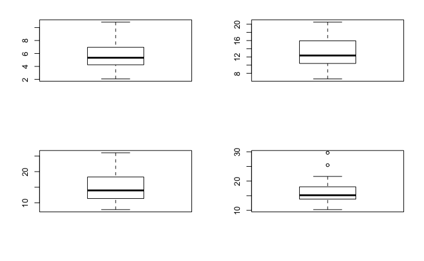

```r
boxplot(normal$NOC2L)
boxplot(cancer$NOC2L)
```

Как видно, в первом случае действительно есть значимое различие у уровнях экспрессии, а во втором случае - нет.

Отметим, что в случае сравнения с группой с сильно выраженными симтомами получилось больше практически и статистически значимых генов.